# Statistical Learning Project

## Data Description:

The data contains the medical costs of people characterized by certain attributes.

### Attribute Information:

1. **Age**: age of primary beneficiary
2. **Sex**: insurance contractor gender, female, male
3. **Bmi**: Body mass index, providing an understanding of body, weights that are relatively high or low relative to height, objective index of body weight (kg / m ^ 2) using the ratio of height to weight, ideally 18.5 to 24.9
4. **Children**: Number of children covered by health insurance / Number of dependents
5. **Smoker**: Smoking
6. **Region**: the beneficiary's residential area in the US, northeast, southeast, southwest, northwest.
7. **Charges**: Individual medical costs billed by health insurance.

This **customer's information** containing **medical costs** with different attributes can be best used for the business purpose like *insurance company*. So, analyzing the data/information to get some requisite requriment is a very invaluable skill to have.

# Analyzing the data with help of statistics

Importing the libraries of statistcs, needed for the purpose of analyzing data

```python
import numpy as np
from numpy import percentile
import pandas as pd
import seaborn as sns
import matplotlib.pyplot as plt
import statistics
from numpy import mean
from scipy import stats
from math import sqrt
from scipy.stats import t
from scipy.stats import ttest_ind
from scipy.stats import ttest_ind_from_stats
from statsmodels.stats.proportion import proportions_ztest
```

## View the data, in form of *data frame*

```python
da=pd.read_csv('insurance.csv')
da.head(10)
```

|  | age | sex | bmi | children | smoker | region | charges |
| --- | --- | --- | --- | --- | --- | --- | --- |
| 0 | 19 | female | 27.900 | 0 | yes | southwest | 16884.92400 |
| 1 | 18 | male | 33.770 | 1 | no | southeast | 1725.55230 |
| 2 | 28 | male | 33.000 | 3 | no | southeast | 4449.46200 |
| 3 | 33 | male | 22.705 | 0 | no | northwest | 21984.47061 |
| 4 | 32 | male | 28.880 | 0 | no | northwest | 3866.85520 |
| 5 | 31 | female | 25.740 | 0 | no | southeast | 3756.62160 |
| 6 | 46 | female | 33.440 | 1 | no | southeast | 8240.58960 |
| 7 | 37 | female | 27.740 | 3 | no | northwest | 7281.50560 |
| 8 | 37 | male | 29.830 | 2 | no | northeast | 6406.41070 |
| 9 | 60 | female | 25.840 | 0 | no | northwest | 28923.13692 |

## *Shape* of data

```python
print('The data contains \nrow = ',da.shape[0],'\ncol = ',da.shape[1])
```

```
The data contains
row =  1338
col =  7
```

## *Data type* of the attributes

```python
print('Data type of each attribute is as follows :')
da.dtypes
```

```
Data type of each attribute is as follows :
```

```
age           int64
sex          object
bmi         float64
children      int64
smoker       object
region       object
charges     float64
dtype: object
```

## Check the missing values

```python
print('Total number of missing values in each column:\n\nColumn   Total Numbers')
print(da.isnull().sum())
```

```
Total number of missing values in each column:

Column   Total Numbers
age         0
sex         0
bmi         0
children    0
smoker      0
region      0
charges     0
dtype: int64
```

## *5 point summary* of numerical attributes

##### Columns having numerical attributes

```python
Col1 = da.dtypes[da.dtypes == np.int64]
Col2 = da.dtypes[da.dtypes == np.float64]

ColumnNames1 = list(Col1.index)
ColumnNames2 = list(Col2.index)
print(ColumnNames1,ColumnNames2)
```

```
['age', 'children'] ['bmi', 'charges']
```

#### 5 point summary is defiened in various quartile given as follows:

> 1. The minimum.
> 2. Q1 (the first quartile, or the 25% mark).
> 3. The median.
> 4. Q3 (the third quartile, or the 75% mark).
> 5. The maximum.

```python
#Arranging values of each column in ascending order
arr = da.sort_values(['age','children','bmi','charges','smoker'])
da.describe()
```

|  | age | bmi | children | charges |
| --- | --- | --- | --- | --- |
| count | 1338.000000 | 1338.000000 | 1338.000000 | 1338.000000 |
| mean | 39.207025 | 30.663397 | 1.094918 | 13270.422265 |
| std | 14.049960 | 6.098187 | 1.205493 | 12110.011237 |
| min | 18.000000 | 15.960000 | 0.000000 | 1121.873900 |
| 25% | 27.000000 | 26.296250 | 0.000000 | 4740.287150 |
| 50% | 39.000000 | 30.400000 | 1.000000 | 9382.033000 |
| 75% | 51.000000 | 34.693750 | 2.000000 | 16639.912515 |
| max | 64.000000 | 53.130000 | 5.000000 | 63770.428010 |

```python
dat=da[['age','bmi','children','charges']]

for x in dat:
    att = da[x]
    print('Attribute: ', x)

    quartiles = percentile(att, [25, 50, 75])
    # calculate min/max
    i_min, a_max = att.min(), att.max()
    # print 5-number summary
    print('S1. Min: %.3f' % i_min)
    print('S2. Q1: %.3f' % quartiles[0])
    print('S3. Median: %.3f' % quartiles[1])
    print('S4. Q3: %.3f' % quartiles[2])
    print('S5. Max: %.3f' % a_max)
    print('\n')
```

```
Attribute:  age
S1. Min: 18.000
S2. Q1: 27.000
S3. Median: 39.000
S4. Q3: 51.000
S5. Max: 64.000


Attribute:  bmi
S1. Min: 15.960
S2. Q1: 26.296
S3. Median: 30.400
S4. Q3: 34.694
S5. Max: 53.130


Attribute:  children
S1. Min: 0.000
S2. Q1: 0.000
S3. Median: 1.000
S4. Q3: 2.000
S5. Max: 5.000


Attribute:  charges
S1. Min: 1121.874
S2. Q1: 4740.287
S3. Median: 9382.033
S4. Q3: 16639.913
S5. Max: 63770.428
```

## Distribution of columns

1. bmi
2. age
3. charges

```
Distribution of ‘bmi’ column
```

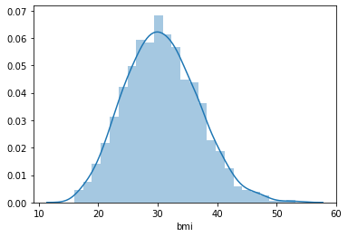

```python
print('Distribution of ‘bmi’ column')
sns.distplot(da['bmi'], kde=True)
```

```
Distribution of ‘age’ column
```

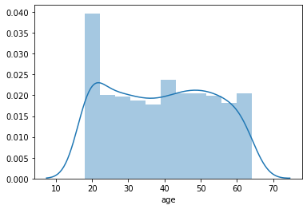

```python
print('Distribution of ‘age’ column')
sns.distplot(da['age'], kde=True)
```

```
Distribution of ‘charges’ column
```

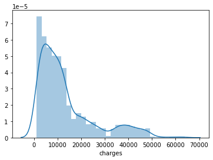

```python
print('Distribution of ‘charges’ column')
sns.distplot(da['charges'], kde=True)
```

## Measure of skewness of columns

1. bmi
2. age
3. charges

```python
dat=da[['bmi','age','charges']]

for x in dat:

    series          = da[x]
    skewness        = series.skew()
    print("Skewness of",x," :",round(skewness,3),'\n')
```

```
Skewness of bmi  : 0.284

Skewness of age  : 0.056

Skewness of charges  : 1.516
```

>

> 1. A skewness value near 0 in the output denotes of symmetrical distribution.
> 2. A negative skewness value in the output indicates an asymmetrical distribution having the tail is larger towards the left hand side of the distribution.
> 3. A positive skewness value in the output indicates an asymmetrical distribution having the tail is larger towards the right hand side of the distribution.

## Checking the presence of outliers in columns

1. bmi
2. age
3. charges

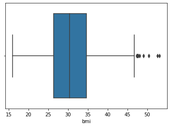

```python
sns.boxplot(da['bmi'])
```

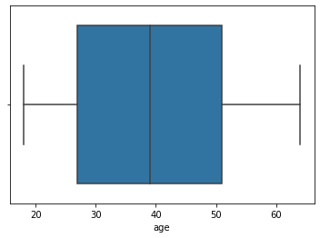

```python
sns.boxplot(da['age'])
```

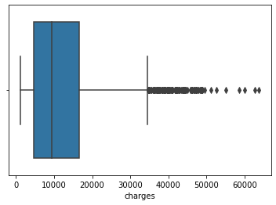

```python
sns.boxplot(da['charges'])
```

```python
dat=da[['bmi','age','charges']]

for x in dat:
    da[x]=da[x].astype(float)
    att = da[x]
    mean = np.mean(att)
    std = np.std(att)
    #print('\nmean of',x,' the dataset is', mean)
   # print('\nstd. deviation of',x,' is', std)
    outlier = []
    outliervalue = []
    for i in att:
        z = (i-mean)/std
        if z < -3.00 or z > 3.00:
            outlier.append(i)
            outliervalue.append(z)
    print('No. of outlier of',x,'in dataset is',len(outlier),'\nWhich are:',outlier,'\n')
```

```
No. of outlier of bmi in dataset is 4
Which are: [49.06, 50.38, 52.58, 53.13]

No. of outlier of age in dataset is 0
Which are: []

No. of outlier of charges in dataset is 7
Which are: [51194.55914, 63770.42801, 58571.074479999996, 55135.402089999996, 52590.82939, 60021.39897, 62592.87309]
```

## Distribution of categorical columns (include children)

##### Columns having categorical attributes

```python
Col3 = da.dtypes[da.dtypes == object]
ColumnNames3 = list(Col3.index)
print(Col3)
```

```
sex       object
smoker    object
region    object
dtype: object
```

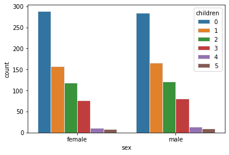

```python
sns.countplot(x='sex',data=da,hue='children',edgecolor=".9")
```

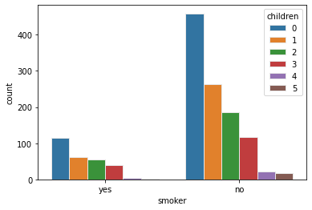

```python
sns.countplot(x='smoker',data=da,hue='children',edgecolor=".9")
```

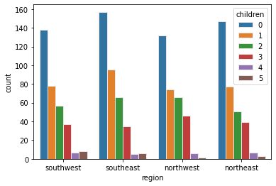

```python
sns.countplot(x='region',data=da,hue='children',edgecolor=".9")
```

## Pair plot of each columns of the data frame

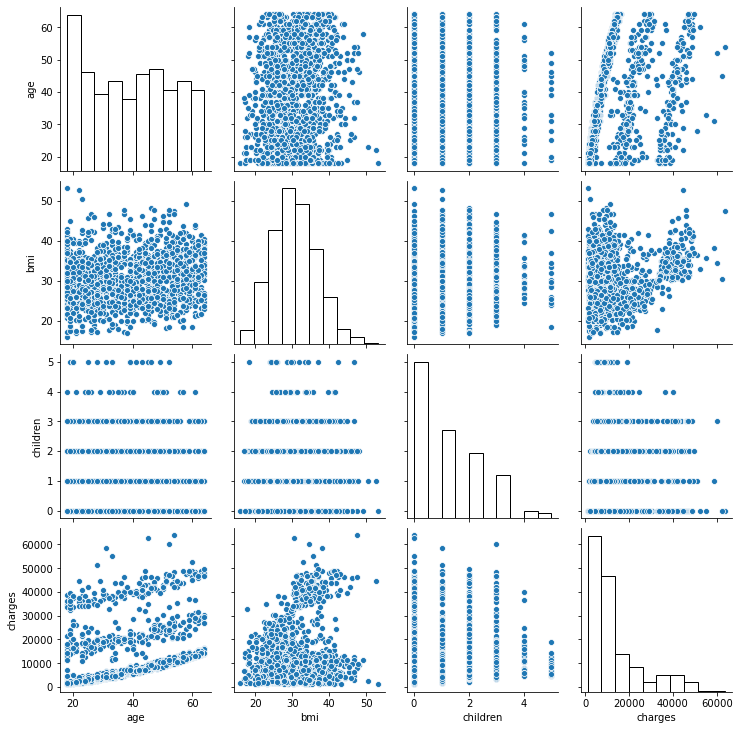

```python
sns.pairplot(da,diag_kws=dict(fill=False))
```

# Predicting using statistical evidence

##### Predicting the charges of people who smoke and the people who don't

```python
print('Grouping total charges of smoker and non-smoker seperately')
ysc = da.loc[da['smoker'] == 'yes', 'charges'].sum()
nsc = da.loc[da['smoker'] == 'no', 'charges'].sum()

print("Total charges for non-smoker : ",nsc)
print("Total charges for smoker: ",ysc)
```

```
Grouping total charges of smoker and non-smoker seperately
Total charges for non-smoker :  8974061.468919002
Total charges for smoker:  8781763.521839999
```

```python
print('Grouping total no of smoker and non-smoker seperately')
da1 = da.sort_values(['smoker','charges'])
da2=da1[['smoker','charges']]

grouped = da2.groupby(da2.smoker)
ys = grouped.get_group("yes")

grouped = da2.groupby(da2.smoker)
ns = grouped.get_group("no")

lys = len(ys)
lns = len(ns)
print('Total No. of smokers are :',lys)
print('Total No. of non-smokers are :',lns)
```

```
Grouping total no of smoker and non-smoker seperately
Total No. of smokers are : 274
Total No. of non-smokers are : 1064
```

```python
print('Grouping tatistical Values of smoker and non-smoker')

yso=ys['charges']
nso=ns['charges']

mean_ys = yso.mean()
std_ys = yso.std()
var_ys=statistics.variance(yso)
print('Mean of charges of smoker is: ',mean_ys)
print('Std D of charges of smoker is:',std_ys)
print("Variance of smoker is % s" %(var_ys))
print('\n')

mean_ns = nso.mean()
std_ns = nso.std()
var_ns=statistics.variance(nso)
print('Mean of charges of non-smoker is:',mean_ns)
print('Std D of charges of non-smoker is:',std_ns)
print("Variance of non-smoker is % s" %(var_ns))
```

```
Grouping tatistical Values of smoker and non-smoker
Mean of charges of smoker is:  32050.231831532856
Std D of charges of smoker is: 11541.54717558912
Variance of smoker is 133207311.20634925


Mean of charges of non-smoker is: 8434.26829785621
Std D of charges of non-smoker is: 5993.781819194935
Variance of non-smoker is 35925420.49611173
```

#### Null hypotheses: Charges of smoker and non-smoker are equal

#### Alternative hypotheses: Charges of smoker and non-smoker are different (two-tailed)

```python
print('Null hypotheses: Charges of smoker and non-smoker are equal')
print('Alternative hypotheses: Charges of smoker and non-smoker are different')
```

```
Null hypotheses: Charges of smoker and non-smoker are equal
Alternative hypotheses: Charges of smoker and non-smoker are different
```

```python
# Run t-test of the data
ind_t_test = stats.ttest_ind(yso,nso)
t_value,p_value=(ind_t_test[0],ind_t_test[1])

# Calculate the mean difference and 95% confidence interval
N1 = lys
N2 = lns
df = (N1 + N2 - 2)
std1 = std_ns
std2 = std_ys
std_N1N2 = sqrt( ((N1 - 1)*(std1)**2 + (N2 - 1)*(std2)**2) / df)
diff_mean = mean_ys - mean_ns
MoE = t.ppf(0.975, df) * std_N1N2 * sqrt(1/N1 + 1/N2)
print('\nThe results of the independent t-test of smoker and non-smoker are: \n\tt-value = {:4.3f}\n\tp-value = {:4.3f}'.format(ind_t_test[0],ind_t_test[1]))

if p_value < .05 :
    print('''\nThe calculated p-value {:4.3f}'''.format(ind_t_test[1]),'''is smaller than the critical p-value : .05 \nThe test concludes that the charges HAS significant effect on smokers and non-smokers so REJECT Null hypotheses: Charges of smoker and non-smoker are equal.''')
else :
    print('''\nThe calculated p-value {:4.3f}'''.format(ind_t_test[1]),'''is greater than the critical p-value : .05 \nThe test concludes that the charges HAS NO effect on significant effect on smokers and non-smokers so ACCEPT Null hypotheses: Charges of smoker and non-smoker are equal.''')
```

```
The results of the independent t-test of smoker and non-smoker are:
	t-value = 46.665
	p-value = 0.000

The calculated p-value 0.000 is smaller than the critical p-value : .05
The test concludes that the charges HAS significant effect on smokers and non-smokers so REJECT Null hypotheses: Charges of smoker and non-smoker are equal.
```

## Does bmi of males differ significantly from that of females?

```python
print('Grouping of total bmi of males and females seperately')
m = da.loc[da['sex'] == 'male', 'bmi'].sum()
f = da.loc[da['sex'] == 'female', 'bmi'].sum()
print("Total bmi of males : ",m)
print("Total bmi of females : ",f)
```

```
Grouping of total bmi of males and females seperately
Total bmi of males :  20917.555
Total bmi of females :  20110.07
```

```python
print('Grouping of total Nos of males and females seperately')

fm1 = da.sort_values(['sex','bmi'])
fm2=fm1[['sex','bmi']]
grouped = fm2.groupby(fm2.sex)
maleg = grouped.get_group("male")

grouped = fm2.groupby(fm2.sex)
femaleg = grouped.get_group("female")

male = len(maleg)
female = len(femaleg)
print('Total No. of males are :',male)
print('Total No. of females are :',female)
```

```
Grouping of total Nos of males and females seperately
Total No. of males are : 676
Total No. of females are : 662
```

```python
bm=maleg['bmi']
bf=femaleg['bmi']
print('Statistics Values of male and female')

mean_bm = bm.mean()
std_bm = bm.std()
print('Mean of bmi of male is: ',mean_bm)
print('Std D of bmi of male is:',std_bm)
print('\n')

mean_bf = bf.mean()
std_bf = bf.std()
print('Mean of bmi of female is:',mean_bf)
print('Std D of bmi of female is:',std_bf)

var_bf=statistics.variance(bf)
print("Variance of bmi of male is % s" %(var_bf))
var_bm=statistics.variance(bm)
print("Variance of bmi of female is % s" %(var_bm))
```

```
Statistics Values of male and female
Mean of bmi of male is:  30.943128698224843
Std D of bmi of male is: 6.140434615792241


Mean of bmi of female is: 30.377749244713023
Std D of bmi of female is: 6.046023085745337
Variance of bmi of male is 36.55439515336554
Variance of bmi of female is 37.704937270819634
```

#### Null hypotheses: Bmi of males and females are same

#### Alternative hypotheses: Bmi of males and females are different (NOT SAME)

```python
print('Null hypotheses: Bmi of males and females are same')
print('Alternative hypotheses: Bmi of males and females are different (NOT SAME)')
```

```
Null hypotheses: Bmi of males and females are same
Alternative hypotheses: Bmi of males and females are different (NOT SAME)
```

```python
# Run t-test of the data
ind_t_test = stats.ttest_ind(bm,bf)
t_value,p_value=(ind_t_test[0],ind_t_test[1])

# Calculate the mean difference and 95% confidence interval
N1 = male
N2 = female
df = (N1 + N2 - 2)
std1 = std_bf
std2 = std_bm
std_N1N2 = sqrt( ((N1 - 1)*(std1)**2 + (N2 - 1)*(std2)**2) / df)

diff_mean = mean_bf - mean_bm
MoE = t.ppf(0.95, df) * std_N1N2 * sqrt(1/N1 + 1/N2)

print('\nThe results of the independent t-test of bmi of males and females are: \n\tt-value = {:4.3f}\n\tp-value = {:4.3f}'.format(ind_t_test[0],ind_t_test[1]))
if p_value < .05 :
    print('''\nThe calculated p-value {:4.3f}'''.format(ind_t_test[1]),'''is smaller than the critical p-value : .05  \nThe test concludes that the bmi HAS significant effect on males and females so REJECT Null hypotheses: Bmi of males and females are same.''')
else :
    print('''\nThe calculated p-value {:4.3f}'''.format(ind_t_test[1]),'''is greater than the critical p-value : .05  \nThe test concludes that the bmi HAS NO effect on significant effect on males and females so ACCEPT Null hypotheses: Bmi of males and females are same.''')
```

```
The results of the independent t-test of bmi of males and females are:
	t-value = 1.697
	p-value = 0.090

The calculated p-value 0.090 is greater than the critical p-value : .05
The test concludes that the bmi HAS NO effect on significant effect on males and females so ACCEPT Null hypotheses: Bmi of males and females are same.
```

## Is the proportion of smokers significantly different in different genders?

```python
print('Grouping total no of smoker and non-smoker seperately')
da1 = da.sort_values(['smoker','charges'])
da2=da1[['smoker','charges']]

grouped = da2.groupby(da2.smoker)
ys = grouped.get_group("yes")

grouped = da2.groupby(da2.smoker)
ns = grouped.get_group("no")

lys = len(ys)
lns = len(ns)
print('Total No. of smokers are :',lys)
print('Total No. of non-smokers are :',lns)
```

```
Grouping total no of smoker and non-smoker seperately
Total No. of smokers are : 274
Total No. of non-smokers are : 1064
```

```python
print('Grouping gender by males and females seperately')

pg1 = da.sort_values(['sex','smoker'])
pg2=pg1[['sex','smoker']]

grouped = pg2.groupby(pg2.sex)
maleg = grouped.get_group("male")
grouped = pg2.groupby(pg2.sex)
femaleg = grouped.get_group("female")

male = len(maleg)
female = len(femaleg)

print('Total No. of males are :',male)
print('Total No. of females are :',female)
```

```
Grouping gender by males and females seperately
Total No. of males are : 676
Total No. of females are : 662
```

```python
print('Grouping Total No of smoker by gender seperately')
pg1 = da.sort_values(['sex','smoker'])
pg2=pg1[['sex','smoker']]
maleg
femaleg

grouped = maleg.groupby(maleg.smoker)
smg = grouped.get_group("yes")

grouped = maleg.groupby(maleg.smoker)
nsmg = grouped.get_group("no")


grouped = femaleg.groupby(femaleg.smoker)
sfg = grouped.get_group("yes")

grouped = femaleg.groupby(femaleg.smoker)
nsfg = grouped.get_group("no")

sm = len(smg)
sf = len(sfg)

nsm = len(nsmg)
nsf = len(nsfg)

print('Total No. of males smoker are :',sm)
print('Total No. of males non - smoker are :',nsm)

print('Total No. of females smoker are :',sf)
print('Total No. of females non - smoker are :',nsf)
```

```
Grouping Total No of smoker by gender seperately
Total No. of males smoker are : 159
Total No. of males non - smoker are : 517
Total No. of females smoker are : 115
Total No. of females non - smoker are : 547
```

#### Assuming hypothesis

Null hypotheses: Proportion of smokers and nonsmoker of *males* and Proportion of smokers and nonsmoker of *females* are *SAME*

Alternative hypotheses: Proportion of smokers and nonsmoker of males and Proportion of smokers and nonsmoker of females are *NOT SAME*

```python
print('Alternative hypotheses: Bmi of males and females are different (NOT SAME)')
print('Null hypotheses: Bmi of males and females are same')
```

```
Alternative hypotheses: Bmi of males and females are different (NOT SAME)
Null hypotheses: Bmi of males and females are same
```

```python
counts = np.array([sm,sf])
nobs = np.array([male,female])

zscore, pvalue = proportions_ztest(counts, nobs, alternative = 'two-sided')
print('\nThe z-score and p-value test of proportion of smoker of males and females are: \n\tZ-score = {:4.3f}\n\tp-value = {:4.3f}'.format(zscore, pvalue))

if pvalue < .05:
    print('''\nThe calculated p-value {:4.3f}'''.format(pvalue),'''is greater than the critical p-value : .05 \nThe test concludes that there is a statistically significant difference between the two proportion.\nI.e. The null hypothesis is rejected.''')
else :
        print('''\nThe calculated p-value {:4.3f}'''.format(pvalue),'''is smaller than the critical p-value : .05 \nThe test concludes that there is a NOT statistically significant difference between the two proportion.\nI.e. the null hypothesis test is TRUE and we REJECT the alternate hypothesis.''')
```

```
The z-score and p-value test of proportion of smoker of males and females are:
	Z-score = 2.787
	p-value = 0.005

The calculated p-value 0.005 is greater than the critical p-value : .05
The test concludes that there is a statistically significant difference between the two proportion.
I.e. The null hypothesis is rejected.
```

## Is the distribution of bmi across women with no children, one child and two children, the same

#### Assuming hypothesis

Null Hypothesis : Different No. of children of women *has no effect* on bmi.

Alternate Hypothesis : Different No. of children of women *has effect* on bmi.

```python
Ho = "Different No. of children of women has no effect on bmi."
Ha = "Different No. of children of women has effect on bmi."

female_df = (da[da['sex'] == 'female'])

zero = female_df[female_df.children == 0]['bmi']
one = female_df[female_df.children == 1]['bmi']
two = female_df[female_df.children == 2]['bmi']


f_stat, p_value = stats.f_oneway(zero,one,two)
print('p_value',p_value)
if p_value < 0.05:
    print(f'{Ha} as the p_value ({p_value.round(3)}) < 0.05')
else:
    print(f'{Ho} as the p_value ({p_value.round(3)}) > 0.05')
```

```
p_value 0.7158579926754841
Different No. of children of women has no effect on bmi. as the p_value (0.716) > 0.05
```